# Exploratory data analysis

# Other information: home and employment status

Overall, there doesn't seem to be any relationship between home status and the interest rate or the FICO score. Furthermore, it makes sense to drop some of the groups like *none* and *other* because of their low number of observations.

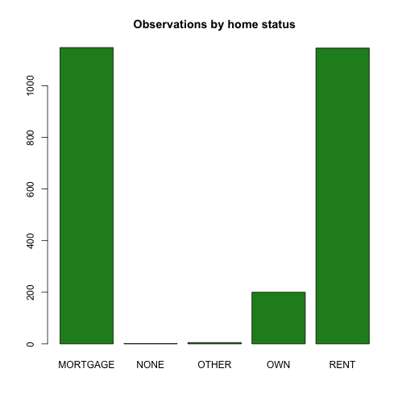

```r
barplot(table(data$Home.Ownership), col = "forest green", main = "Observations by home status")
```

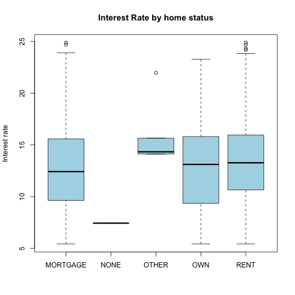

```r
with(data, boxplot(Interest.Rate ~ Home.Ownership, col = "light blue", main = "Interest Rate by home status",
    ylab = "Interest rate"))
```

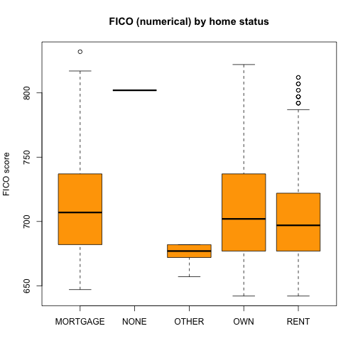

```r
with(data, boxplot(FICO.num ~ Home.Ownership, col = "orange", main = "FICO (numerical) by home status",
    ylab = "FICO score"))
```

Regarding the employment length, well, the data suggests that there is no relationship between this variable and the variables of interest. For instance, the median interest rate is the same for those employed less than a year and those with 10 or more years of employment. The means are also fairly close.

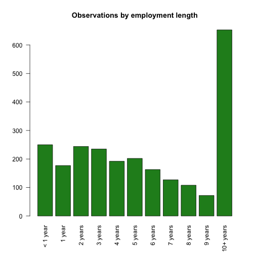

```r
data$Employment.Length.Mod <- factor(data$Employment.Length, levels = c("< 1 year",
    "1 year", "2 years", "3 years", "4 years", "5 years", "6 years", "7 years",
    "8 years", "9 years", "10+ years"), ordered = TRUE)
barplot(table(data$Employment.Length.Mod), col = "forest green", main = "Observations by employment length",
    las = 2)
```

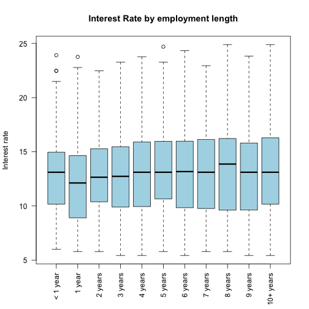

```r
with(data, boxplot(Interest.Rate ~ Employment.Length.Mod, col = "light blue",
    main = "Interest Rate by employment length", ylab = "Interest rate", las = 2))
```

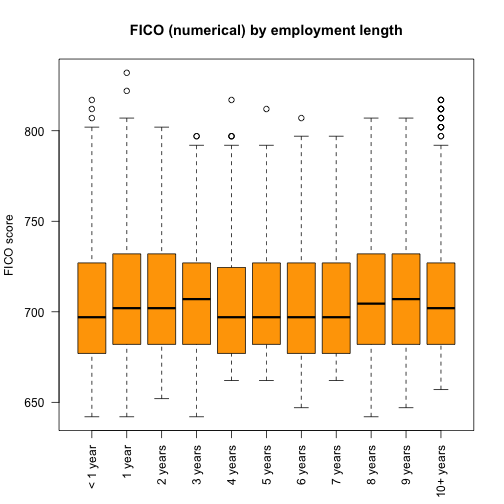

```r
with(data, boxplot(FICO.num ~ Employment.Length.Mod, col = "orange", main = "FICO (numerical) by employment length",
    ylab = "FICO score", las = 2))
```

```r
tapply(data$Interest.Rate, data$Employment.Length.Mod, mean)
```

```
##  < 1 year    1 year   2 years   3 years   4 years   5 years   6 years
##     12.85     12.49     12.85     12.77     13.14     13.40     13.29
##   7 years   8 years   9 years 10+ years
##     13.10     13.01     13.15     13.34
```

```r
tapply(data$Interest.Rate, data$Employment.Length.Mod, median)
```

```
##  < 1 year    1 year   2 years   3 years   4 years   5 years   6 years
##     13.11     12.12     12.65     12.73     13.11     13.11     13.17
##   7 years   8 years   9 years 10+ years
##     13.11     13.87     13.11     13.11
```

# postprocess() function

This EDA lead to the creation of the `postprocess()` function that re-arranges some of the variables.

```r
ready <- postprocess(data)
```

```
## Removing the earliest credit line information for 4 observations.
```

```r
head(ready)
```

```
##   Amount.Requested Amount.Funded.By.Investors Interest.Rate Loan.Length
## 1            20000                      20000          8.90          36
## 2            19200                      19200         12.12          36
## 3            35000                      35000         21.98          60
## 4            10000                       9975          9.99          36
## 5            12000                      12000         11.71          36
## 6             6000                       6000         15.31          36
##   Debt.To.Income.Ratio Open.CREDIT.Lines Inquiries.in.the.Last.6.Months
## 1                14.90                14                              2
## 2                28.36                12                              1
## 3                23.81                14                              1
## 4                14.30                10                              0
## 5                18.78                11                              0
## 6                20.05                17                              2
##   Issued.Date Earliest.CREDIT.Line Total.CREDIT.Lines State.Region
```

[output cut: 20 more lines]

```r
summary(ready)
```

```
##  Amount.Requested Amount.Funded.By.Investors Interest.Rate
##  Min.   : 1000    Min.   :    0              Min.   : 5.42
##  1st Qu.: 6000    1st Qu.: 6000              1st Qu.:10.16
##  Median :10000    Median :10000              Median :13.11
##  Mean   :12406    Mean   :12002              Mean   :13.07
##  3rd Qu.:17000    3rd Qu.:16000              3rd Qu.:15.80
##  Max.   :35000    Max.   :35000              Max.   :24.89
##
##   Loan.Length   Debt.To.Income.Ratio Open.CREDIT.Lines
##  Min.   :36.0   Min.   : 0.00        Min.   : 2.0
##  1st Qu.:36.0   1st Qu.: 9.75        1st Qu.: 7.0
##  Median :36.0   Median :15.32        Median : 9.0
##  Mean   :41.3   Mean   :15.38        Mean   :10.1
##  3rd Qu.:36.0   3rd Qu.:20.67        3rd Qu.:13.0
##  Max.   :60.0   Max.   :34.91        Max.   :38.0
##                                      NA's   :2
##  Inquiries.in.the.Last.6.Months  Issued.Date         Earliest.CREDIT.Line
##  Min.   :0.000                  Min.   :2007-06-16   Min.   :1969-05-20
##  1st Qu.:0.000                  1st Qu.:2011-03-31   1st Qu.:1994-09-05
##  Median :0.000                  Median :2012-03-09   Median :1998-12-30
##  Mean   :0.906                  Mean   :2011-10-23   Mean   :1997-09-30
##  3rd Qu.:1.000                  3rd Qu.:2012-09-17   3rd Qu.:2002-01-18
##  Max.   :9.000                  Max.   :2013-01-18   Max.   :2009-03-28
##  NA's   :2                      NA's   :73           NA's   :6
##  Total.CREDIT.Lines  State.Region    FICO.num   Employment.Length.Mod
##  Min.   : 3         09     :523   Min.   :642   10+ years:653
##  1st Qu.:15         04     :421   1st Qu.:682   < 1 year :250
##  Median :22         02     :349   Median :702   2 years  :244
##  Mean   :23         05     :284   Mean   :708   3 years  :235
##  3rd Qu.:30         03     :276   3rd Qu.:727   5 years  :202
##  Max.   :63         06     :243   Max.   :832   (Other)  :839
##  NA's   :2          (Other):404                 NA's     : 77
##  Monthly.Income.Log           Loan.Purpose.Mod Home.Ownership.Mod
##  Min.   : 6.38      credit_card       : 444    MORTGAGE:1148
##  1st Qu.: 8.16      debt_consolidation:1307    OWN     : 200
##  Median : 8.52      other             : 749    RENT    :1146
##  Mean   : 8.50                                 NA's    :   6
##  3rd Qu.: 8.82
##  Max.   :11.54
##  NA's   :1
##  Revolving.CREDIT.Balance.log
##  Min.   : 0.00
##  1st Qu.: 8.63
##  Median : 9.30
##  Mean   : 9.03
##  3rd Qu.: 9.85
##  Max.   :12.51
##  NA's   :2
```

```r
print(proc.time())
```

```
##    user  system elapsed
##  15.040   0.871 212.833
```